# ExtraaLearn Project

## Context

The EdTech industry has been surging in the past decade immensely, and according to a forecast, the Online Education market would be worth $286.62bn by 2023 with a compound annual growth rate (CAGR) of 10.26% from 2018 to 2023. The modern era of online education has enforced a lot in its growth and expansion beyond any limit. Due to having many dominant features like ease of information sharing, personalized learning experience, transparency of assessment, etc, it is now preferable to traditional education.

In the present scenario due to the Covid-19, the online education sector has witnessed rapid growth and is attracting a lot of new customers. Due to this rapid growth, many new companies have emerged in this industry. With the availability and ease of use of digital marketing resources, companies can reach out to a wider audience with their offerings. The customers who show interest in these offerings are termed as leads. There are various sources of obtaining leads for Edtech companies, like

- The customer interacts with the marketing front on social media or other online platforms.
- The customer browses the website/app and downloads the brochure
- The customer connects through emails for more information.

The company then nurtures these leads and tries to convert them to paid customers. For this, the representative from the organization connects with the lead on call or through email to share further details.

## Objective

ExtraaLearn is an initial stage startup that offers programs on cutting-edge technologies to students and professionals to help them upskill/reskill. With a large number of leads being generated on a regular basis, one of the issues faced by ExtraaLearn is to identify which of the leads are more likely to convert so that they can allocate resources accordingly. You, as a data scientist at ExtraaLearn, have been provided the leads data to:

- Analyze and build an ML model to help identify which leads are more likely to convert to paid customers,
- Find the factors driving the lead conversion process
- Create a profile of the leads which are likely to convert

## Data Description

The data contains the different attributes of leads and their interaction details with ExtraaLearn. The detailed data dictionary is given below.

**Data Dictionary**

- ID: ID of the lead
- age: Age of the lead
- current_occupation: Current occupation of the lead. Values include 'Professional','Unemployed',and 'Student'
- first_interaction: How did the lead first interacted with ExtraaLearn. Values include 'Website', 'Mobile App'
- profile_completed: What percentage of profile has been filled by the lead on the website/mobile app. Values include Low - (0-50%), Medium - (50-75%), High (75-100%)
- website_visits: How many times has a lead visited the website
- time_spent_on_website: Total time spent on the website
- page_views_per_visit: Average number of pages on the website viewed during the visits.
- last_activity: Last interaction between the lead and ExtraaLearn.
  - Email Activity: Seeking for details about program through email, Representative shared information with lead like brochure of program , etc
  - Phone Activity: Had a Phone Conversation with representative, Had conversation over SMS with representative, etc
  - Website Activity: Interacted on live chat with representative, Updated profile on website, etc
- print_media_type1: Flag indicating whether the lead had seen the ad of ExtraaLearn in the Newspaper.
- print_media_type2: Flag indicating whether the lead had seen the ad of ExtraaLearn in the Magazine.
- digital_media: Flag indicating whether the lead had seen the ad of ExtraaLearn on the digital platforms.
- educational_channels: Flag indicating whether the lead had heard about ExtraaLearn in the education channels like online forums, discussion threads, educational websites, etc.
- referral: Flag indicating whether the lead had heard about ExtraaLearn through reference.
- status: Flag indicating whether the lead was converted to a paid customer or not.

## Importing necessary libraries and data

```python
# Suppress warnings (helps keep the output clean)
import warnings
warnings.filterwarnings("ignore")


import pandas as pd  # For working with dataframes
import numpy as np  # For numerical computations


import matplotlib.pyplot as plt  # For creating plots
import seaborn as sns  # For visualizations
sns.set()  # stylying seaborn


from sklearn.tree import DecisionTreeClassifier  # Decision Tree Classifier
from sklearn.ensemble import RandomForestClassifier  # Random Forest Classifier


from sklearn.model_selection import train_test_split  # To split data into training and testing sets
from sklearn.preprocessing import MinMaxScaler, LabelEncoder, OneHotEncoder  # For scaling and encoding data
from sklearn.impute import SimpleImputer  # To handle missing values

from sklearn.metrics import (
    accuracy_score,
    recall_score,
    precision_score,
    f1_score,
    confusion_matrix,
    classification_report,
    roc_auc_score,
    precision_recall_curve,
    roc_curve
)


from sklearn.model_selection import GridSearchCV  # To find the best model parameters
```

```python
from google.colab import drive
drive.mount('/content/drive')
```

```python
data = pd.read_csv("/content/drive/MyDrive/ColabNotebooks/MITPython/ProjectEducation/ExtraaLearn.csv")
```

## Data Overview

- Observations
- Sanity checks

```python
data.head()
```

|  | ID | age | current_occupation | first_interaction | profile_completed | website_visits | time_spent_on_website | page_views_per_visit | last_activity | print_media_type1 | print_media_type2 | digital_media | educational_channels | referral | status |
| --- | --- | --- | --- | --- | --- | --- | --- | --- | --- | --- | --- | --- | --- | --- | --- |
| 0 | EXT001 | 57 | Unemployed | Website | High | 7 | 1639 | 1.861 | Website Activity | Yes | No | Yes | No | No | 1 |
| 1 | EXT002 | 56 | Professional | Mobile App | Medium | 2 | 83 | 0.320 | Website Activity | No | No | No | Yes | No | 0 |
| 2 | EXT003 | 52 | Professional | Website | Medium | 3 | 330 | 0.074 | Website Activity | No | No | Yes | No | No | 0 |
| 3 | EXT004 | 53 | Unemployed | Website | High | 4 | 464 | 2.057 | Website Activity | No | No | No | No | No | 1 |
| 4 | EXT005 | 23 | Student | Website | High | 4 | 600 | 16.914 | Email Activity | No | No | No | No | No | 0 |

```python
data.tail()
```

|  | ID | age | current_occupation | first_interaction | profile_completed | website_visits | time_spent_on_website | page_views_per_visit | last_activity | print_media_type1 | print_media_type2 | digital_media | educational_channels | referral | status |
| --- | --- | --- | --- | --- | --- | --- | --- | --- | --- | --- | --- | --- | --- | --- | --- |
| 4607 | EXT4608 | 35 | Unemployed | Mobile App | Medium | 15 | 360 | 2.170 | Phone Activity | No | No | No | Yes | No | 0 |
| 4608 | EXT4609 | 55 | Professional | Mobile App | Medium | 8 | 2327 | 5.393 | Email Activity | No | No | No | No | No | 0 |
| 4609 | EXT4610 | 58 | Professional | Website | High | 2 | 212 | 2.692 | Email Activity | No | No | No | No | No | 1 |
| 4610 | EXT4611 | 57 | Professional | Mobile App | Medium | 1 | 154 | 3.879 | Website Activity | Yes | No | No | No | No | 0 |
| 4611 | EXT4612 | 55 | Professional | Website | Medium | 4 | 2290 | 2.075 | Phone Activity | No | No | No | No | No | 0 |

```python
data.shape
```

```
(4612, 15)
```

```python
data.dtypes
```

|  | 0 |
| --- | --- |
| ID | object |
| age | int64 |
| current_occupation | object |
| first_interaction | object |
| profile_completed | object |
| website_visits | int64 |
| time_spent_on_website | int64 |
| page_views_per_visit | float64 |
| last_activity | object |
| print_media_type1 | object |
| print_media_type2 | object |
| digital_media | object |
| educational_channels | object |
| referral | object |
| status | int64 |

**dtype:** object

one float, the rest are intergers and objects.

1. Remove ID

```python
data.duplicated().sum()
```

```
0
```

No dupplicates in the data

```python
datatest = data.copy()
```

Making a copy so that I don't modify the original data accidentally.

## Exploratory Data Analysis (EDA)

- EDA is an important part of any project involving data.
- It is important to investigate and understand the data better before building a model with it.
- A few questions have been mentioned below which will help you approach the analysis in the right manner and generate insights from the data.
- A thorough analysis of the data, in addition to the questions mentioned below, should be done.

**Questions**

1. Leads will have different expectations from the outcome of the course and the current occupation may play a key role in getting them to participate in the program. Find out how current occupation affects lead status.
2. The company's first impression on the customer must have an impact. Do the first channels of interaction have an impact on the lead status?
3. The company uses multiple modes to interact with prospects. Which way of interaction works best?
4. The company gets leads from various channels such as print media, digital media, referrals, etc. Which of these channels have the highest lead conversion rate?
5. People browsing the website or mobile application are generally required to create a profile by sharing their personal data before they can access additional information.Does having more details about a prospect increase the chances of conversion?

```python
datatest.isnull().sum()
```

|  | 0 |
| --- | --- |
| ID | 0 |
| age | 0 |
| current_occupation | 0 |
| first_interaction | 0 |
| profile_completed | 0 |
| website_visits | 0 |
| time_spent_on_website | 0 |
| page_views_per_visit | 0 |
| last_activity | 0 |
| print_media_type1 | 0 |
| print_media_type2 | 0 |
| digital_media | 0 |
| educational_channels | 0 |
| referral | 0 |
| status | 0 |

**dtype:** int64

No null data, we can proceed normally.

```python
datatest.info()
```

```
<class 'pandas.core.frame.DataFrame'>
RangeIndex: 4612 entries, 0 to 4611
Data columns (total 15 columns):
 #   Column                 Non-Null Count  Dtype
---  ------                 --------------  -----
 0   ID                     4612 non-null   object
 1   age                    4612 non-null   int64
 2   current_occupation     4612 non-null   object
 3   first_interaction      4612 non-null   object
 4   profile_completed      4612 non-null   object
 5   website_visits         4612 non-null   int64
 6   time_spent_on_website  4612 non-null   int64
 7   page_views_per_visit   4612 non-null   float64
 8   last_activity          4612 non-null   object
 9   print_media_type1      4612 non-null   object
 10  print_media_type2      4612 non-null   object
 11  digital_media          4612 non-null   object
 12  educational_channels   4612 non-null   object
 13  referral               4612 non-null   object
 14  status                 4612 non-null   int64
dtypes: float64(1), int64(4), object(10)
memory usage: 540.6+ KB
```

```python
datatest.describe()
```

|  | age | website_visits | time_spent_on_website | page_views_per_visit | status |
| --- | --- | --- | --- | --- | --- |
| count | 4612.000000 | 4612.000000 | 4612.000000 | 4612.000000 | 4612.000000 |
| mean | 46.201214 | 3.566782 | 724.011275 | 3.026126 | 0.298569 |
| std | 13.161454 | 2.829134 | 743.828683 | 1.968125 | 0.457680 |
| min | 18.000000 | 0.000000 | 0.000000 | 0.000000 | 0.000000 |
| 25% | 36.000000 | 2.000000 | 148.750000 | 2.077750 | 0.000000 |
| 50% | 51.000000 | 3.000000 | 376.000000 | 2.792000 | 0.000000 |
| 75% | 57.000000 | 5.000000 | 1336.750000 | 3.756250 | 1.000000 |
| max | 63.000000 | 30.000000 | 2537.000000 | 18.434000 | 1.000000 |

**Age: I think people seem to be older, the median is 51 and the mean is 46. The minimum age is 18, so there are no minors. The max age is 63, which interestinly enough its not far from the 75%.**

**Website_visits: There are a few visits, the mean being 3.5 and the median being 3. There might be a potential outlier as the max is 30. People don't visit the website much in general.**

**Time_spent_on_website: Althought people don't visit the website much, people still spend time on the website. I'm not sure if this is minutes or seconds (as people can leave the website open), but the mean is 724. I imagine its seconds, as 724 is 12 minutes on average on the website. Just enough to investigate and get more info out of the website and througly search. The max value might be another outlier as it doubles from the 75%, but not too sure.**

The code only gave me numerical values so it's important to investigate the categorical as well.

```python
datatest.describe(include=["object"]).T
```

|  | count | unique | top | freq |
| --- | --- | --- | --- | --- |
| ID | 4612 | 4612 | EXT001 | 1 |
| current_occupation | 4612 | 3 | Professional | 2616 |
| first_interaction | 4612 | 2 | Website | 2542 |
| profile_completed | 4612 | 3 | High | 2264 |
| last_activity | 4612 | 3 | Email Activity | 2278 |
| print_media_type1 | 4612 | 2 | No | 4115 |
| print_media_type2 | 4612 | 2 | No | 4379 |
| digital_media | 4612 | 2 | No | 4085 |
| educational_channels | 4612 | 2 | No | 3907 |
| referral | 4612 | 2 | No | 4519 |

```python
datatest.drop(["ID"], axis = 1, inplace = True) #ID wont give us any value so it's better to just drop it
```

Most people are professionals, their first interaction is the website, their profile is completed, the last activity is thorugh email.

```python
for i in datatest.describe(include=["object"]).columns:
    print(datatest[i].value_counts())
    print("*" * 50)
```

```
current_occupation
Professional    2616
Unemployed      1441
Student          555
Name: count, dtype: int64
first_interaction
Website       2542
Mobile App    2070
Name: count, dtype: int64
profile_completed
High      2264
Medium    2241
Low        107
Name: count, dtype: int64
last_activity
Email Activity      2278
Phone Activity      1234
Website Activity    1100
Name: count, dtype: int64
print_media_type1
No     4115
Yes     497
Name: count, dtype: int64
print_media_type2
No     4379
Yes     233
Name: count, dtype: int64
digital_media
No     4085
Yes     527
Name: count, dtype: int64
educational_channels
No     3907
Yes     705
Name: count, dtype: int64
referral
No     4519
Yes      93
Name: count, dtype: int64
```

# Univariate Analysis

```python
def hist_box(datatest, feature, figsize=(12, 7), kde=False, bins=None):
  #So basically this function shows two plots together, which is the box plot and the histogram to save time.
  #the feature is the column name we want to analyze, figsize is the size of the plot



    # Create a figure with two plots (boxplot on top, histogram on the bottom)
    f, (ax_box, ax_hist) = plt.subplots(
        nrows=2,   # Two rows of plots
        sharex=True,   # Share the x-axis between plots
        gridspec_kw={"height_ratios": (0.25, 0.75)},   # Control the size ratio of the plots
        figsize=figsize   # Set the size of the figure
    )

    sns.boxplot(data=datatest, x=feature, ax=ax_box, showmeans=True, color="skyblue")

    if bins:
        sns.histplot(data=datatest, x=feature, kde=kde, ax=ax_hist, bins=bins, palette="coolwarm")  # Cool-warm gradient palette
    else:
        sns.histplot(data=datatest, x=feature, kde=kde, ax=ax_hist, palette="viridis")  # Viridis palette

    # Add lines for the mean and median in the histogram
    ax_hist.axvline(datatest[feature].mean(), color="red", linestyle="--")   # Mean (red, dashed line)
    ax_hist.axvline(datatest[feature].median(), color="black", linestyle="-")   # Median (black, solid line)

    # Show the plot
    plt.show()
```

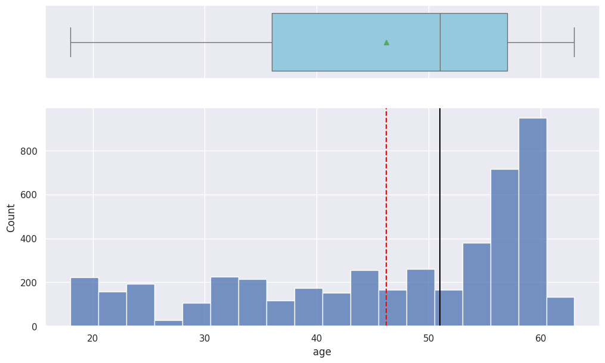

```python
hist_box(datatest, "age")
```

The information isn't distributed normally and it's left skewed. Majority of the users are aged above 50.

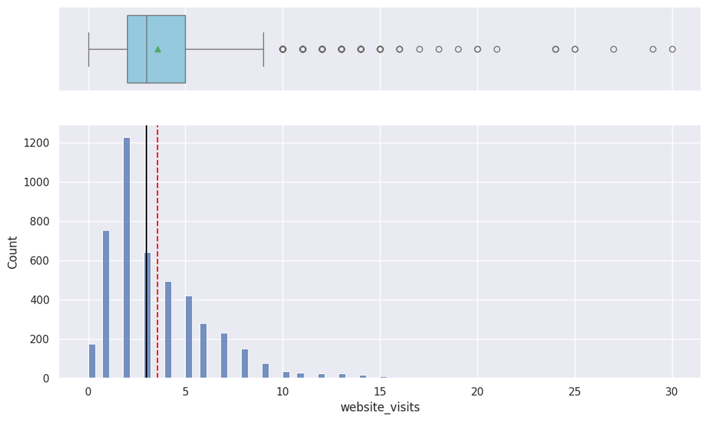

```python
hist_box(datatest, "website_visits")
```

There are many outliers, all above 10. The information is lightly right skewed. The mode and mean are below 5

```python
datatest[datatest["website_visits"] == 0].shape #we are checking how many people have not visited the website, so in total its 174
```

```
(174, 14)
```

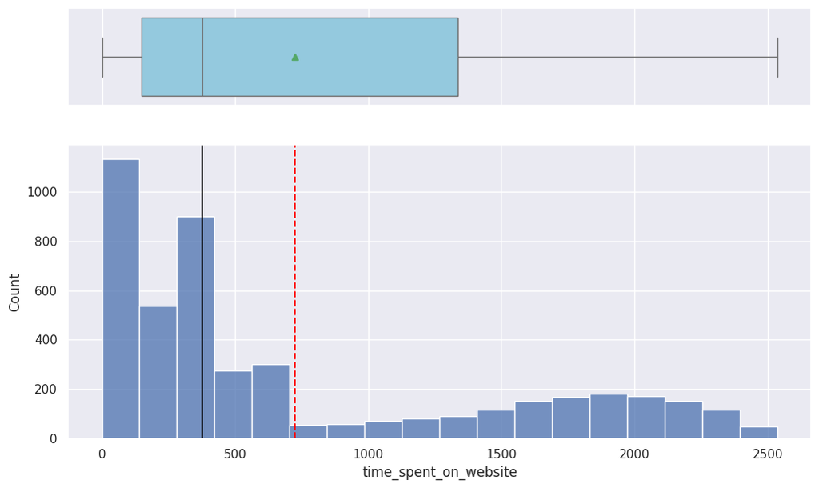

```python
hist_box(datatest, "time_spent_on_website")
```

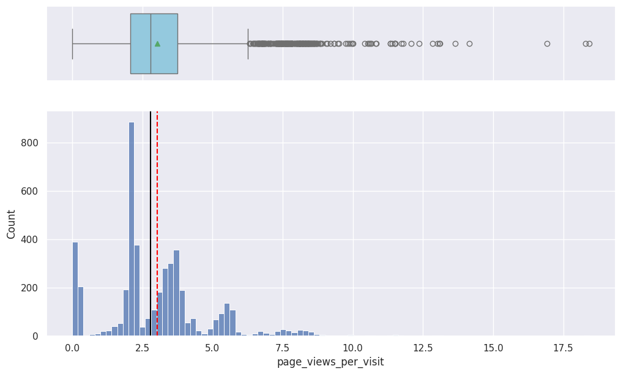

```python
hist_box(datatest, "page_views_per_visit")
```

```python
unique_values = datatest['page_views_per_visit'].nunique()
print("Number of unique values in 'page_views_per_visit':", unique_values)
```

```
Number of unique values in 'page_views_per_visit': 2414
```

```python
#function to create a barplot and not have to do the same code over and over again we just call this function
def barp(datatest, feature, perc=False, n=None, palette="coolwarm"):

    total = len(datatest[feature])  # Total count in the column
    count = datatest[feature].nunique()  # Number of unique categories

    plt.figure(figsize=(min(count, 10) + 3, 5))  # Dynamic figure size

    ax = sns.countplot(
        data=datatest,
        x=feature,
        palette=palette,  # Custom color scheme
        order=datatest[feature].value_counts().index[:n] if n else datatest[feature].value_counts().index
    )

    # Add labels on top of each bar
    for p in ax.patches:
        value = p.get_height()
        label = f"{100 * value / total:.1f}%" if perc else f"{value:,}"

        # Determine text color (white for dark bars, black for light bars)
        text_color = "white" if p.get_facecolor()[:3] < (0.5, 0.5, 0.5) else "black"

        ax.annotate(
            label,
            (p.get_x() + p.get_width() / 2, value),
            ha="center", va="bottom", fontsize=12, color=text_color,
            xytext=(0, 5), textcoords="offset points"
        )

    plt.xticks(rotation=45, fontsize=12)
    plt.xlabel(feature, fontsize=14)
    plt.ylabel("Count" if not perc else "Percentage", fontsize=14)
    plt.title(f"Distribution of {feature}", fontsize=16)
    plt.show()
```

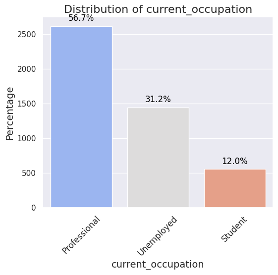

```python
barp(datatest, "current_occupation", perc=True)
```

Most of the people interested seem to be professionals, followed by unemployed people then students.

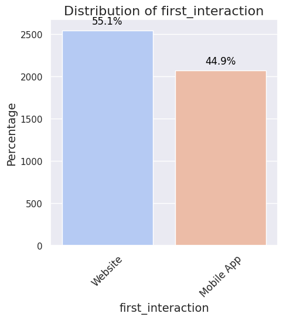

```python
barp(datatest, "first_interaction", perc=True)
```

The website has the highest rate of first interaction, then the mobile app. This means it might be a priority to improve the website rather than the mobile app as it handles higher traffic.

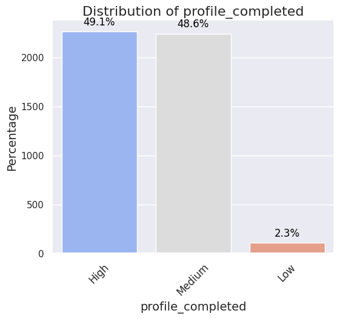

```python
barp(datatest, "profile_completed", perc=True)
```

People seem to complete their profiles either at high rates or medium, but barely low. Low profile completion is rare.

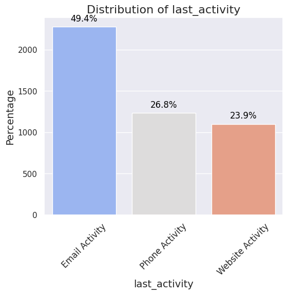

```python
barp(datatest, "last_activity", perc=True)
```

The last highest activity is email, while phone activity and website activity seem close. The highest engangement might be email.

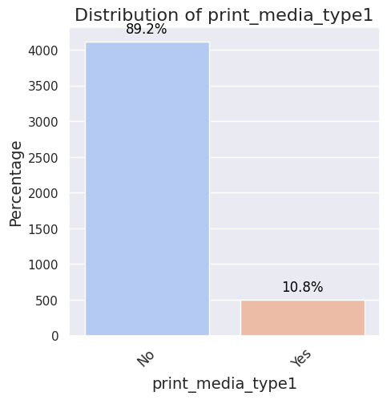

```python
barp(datatest, "print_media_type1", perc=True)
```

News paper in comparasion to other media types brings in decent clientele.

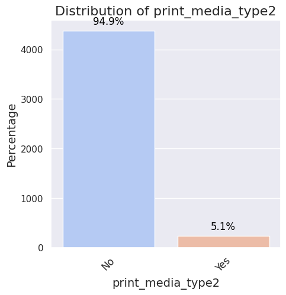

```python
barp(datatest, "print_media_type2", perc=True)
```

Magazine might not be the best choice to bringing in new clients, as only 5.1% come from there. It's a good choice to stop using this media to attract choices all together.

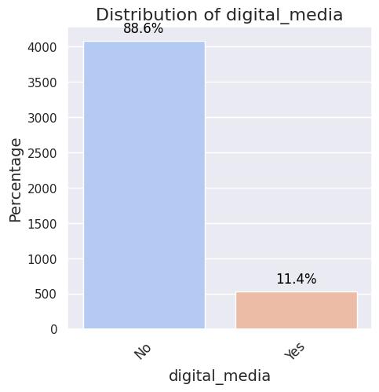

```python
barp(datatest, "digital_media", perc=True)
```

Digitial media brings in decent clients.

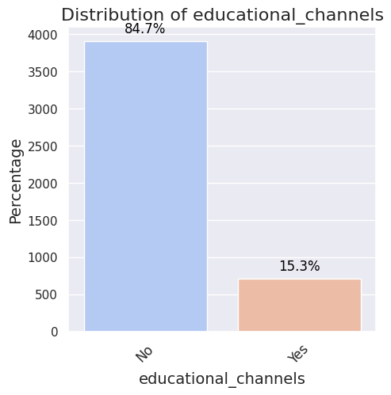

```python
barp(datatest, "educational_channels", perc=True)
```

Educational channels attract the most clients, so it might be a good choice to make a deal with schools/educational channels to be recommended to interested people.

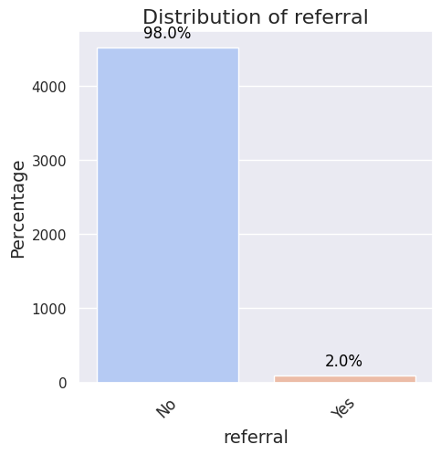

```python
barp(datatest, "referral", perc=True)
```

Referrals are few, it might be a good choice to make deals of giving discounts to several people.

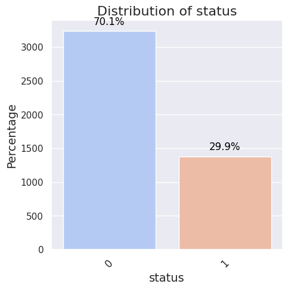

```python
barp(datatest, "status", perc=True)
```

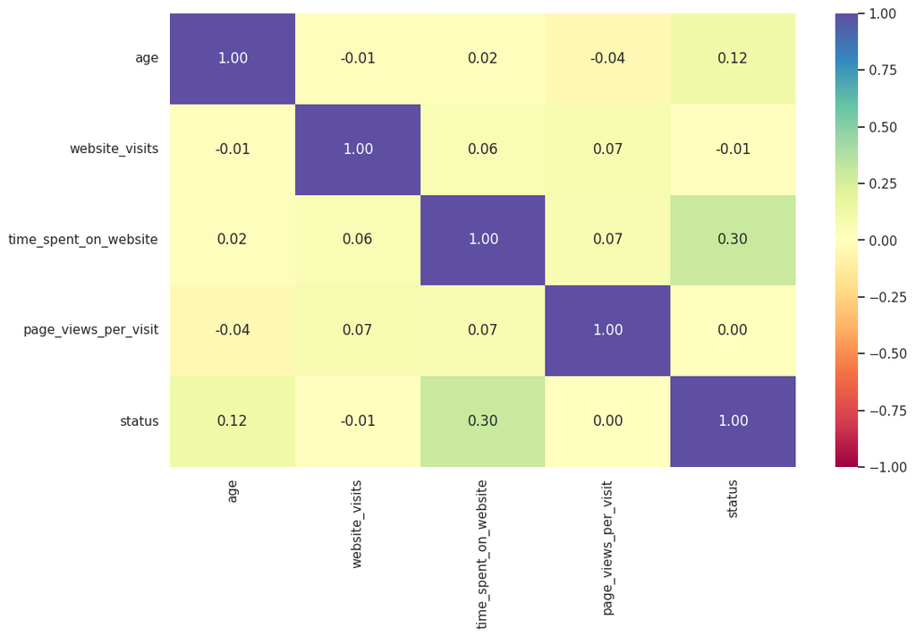

```python
cols_list = datatest.select_dtypes(include=np.number).columns.tolist()

plt.figure(figsize=(12, 7))
sns.heatmap(
    data[cols_list].corr(), annot=True, vmin=-1, vmax=1, fmt=".2f", cmap="Spectral"
)
plt.show()
```

```
status                0     1   All
first_interaction
Mobile App         1852   218  2070
Website            1383  1159  2542
All                3235  1377  4612
------------------------------------------------------------------------------------------------------------------------
```

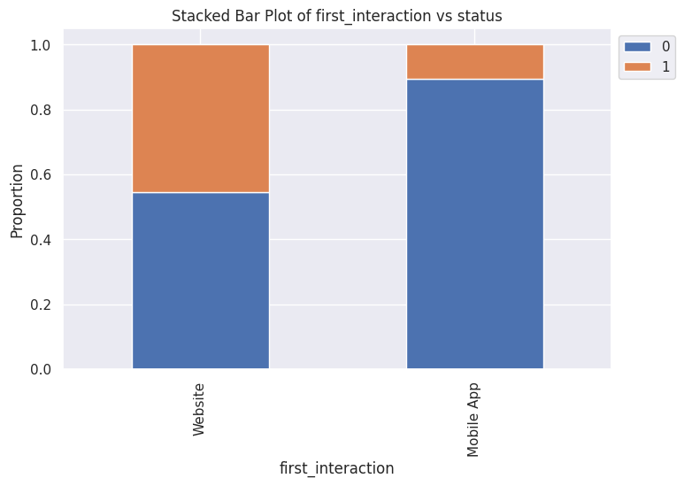

```python
predictor = "first_interaction"
target = "status"

# Crosstab for raw counts
table_counts = pd.crosstab(datatest[predictor], datatest[target], margins=True)
print(table_counts)
print("-" * 120)

# Crosstab for normalized percentages
table_norm = pd.crosstab(datatest[predictor], datatest[target], normalize="index")

# Sorting by the least frequent target value
sorter = datatest[target].value_counts().index[-1]
table_norm = table_norm.sort_values(by=sorter, ascending=False)

# Plot stacked bar chart
table_norm.plot(kind="bar", stacked=True, figsize=(8, 5))

plt.legend(loc="upper left", bbox_to_anchor=(1, 1))
plt.xlabel(predictor)
plt.ylabel("Proportion")
plt.title(f"Stacked Bar Plot of {predictor} vs {target}")
plt.show()
```

Since there is a correlation between time spent on website and the status, we can clearly see it on the website. I'm not sure if that rate also translates to the mobile app, but we can see that users are more highly convinced to convert on the website.

```
status                0     1   All
profile_completed
High               1318   946  2264
Low                  99     8   107
Medium             1818   423  2241
All                3235  1377  4612
------------------------------------------------------------------------------------------------------------------------
```

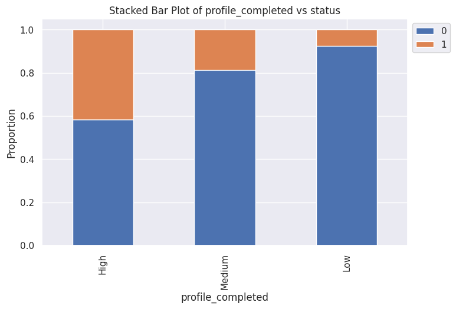

```python
predictor = "profile_completed"
target = "status"

# Crosstab for raw counts
table_counts = pd.crosstab(datatest[predictor], datatest[target], margins=True)
print(table_counts)
print("-" * 120)

# Crosstab for normalized percentages
table_norm = pd.crosstab(datatest[predictor], datatest[target], normalize="index")

# Sorting by the least frequent target value
sorter = datatest[target].value_counts().index[-1]
table_norm = table_norm.sort_values(by=sorter, ascending=False)

# Plot stacked bar chart
table_norm.plot(kind="bar", stacked=True, figsize=(8, 5))

plt.legend(loc="upper left", bbox_to_anchor=(1, 1))
plt.xlabel(predictor)
plt.ylabel("Proportion")
plt.title(f"Stacked Bar Plot of {predictor} vs {target}")
plt.show()
```

It's logical that people who are highly interested will make further effort to complete their profile.

```
status                0     1   All
print_media_type1
No                 2897  1218  4115
Yes                 338   159   497
All                3235  1377  4612
------------------------------------------------------------------------------------------------------------------------
```

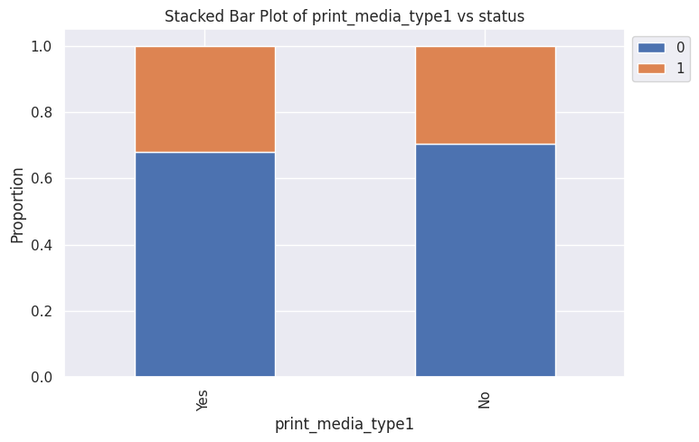

```python
predictor = "print_media_type1"
target = "status"

# Crosstab for raw counts
table_counts = pd.crosstab(datatest[predictor], datatest[target], margins=True)
print(table_counts)
print("-" * 120)

# Crosstab for normalized percentages
table_norm = pd.crosstab(datatest[predictor], datatest[target], normalize="index")

# Sorting by the least frequent target value
sorter = datatest[target].value_counts().index[-1]
table_norm = table_norm.sort_values(by=sorter, ascending=False)

# Plot stacked bar chart
table_norm.plot(kind="bar", stacked=True, figsize=(8, 5))

plt.legend(loc="upper left", bbox_to_anchor=(1, 1))
plt.xlabel(predictor)
plt.ylabel("Proportion")
plt.title(f"Stacked Bar Plot of {predictor} vs {target}")
plt.show()
```

```
status                0     1   All
print_media_type2
No                 3077  1302  4379
Yes                 158    75   233
All                3235  1377  4612
------------------------------------------------------------------------------------------------------------------------
```

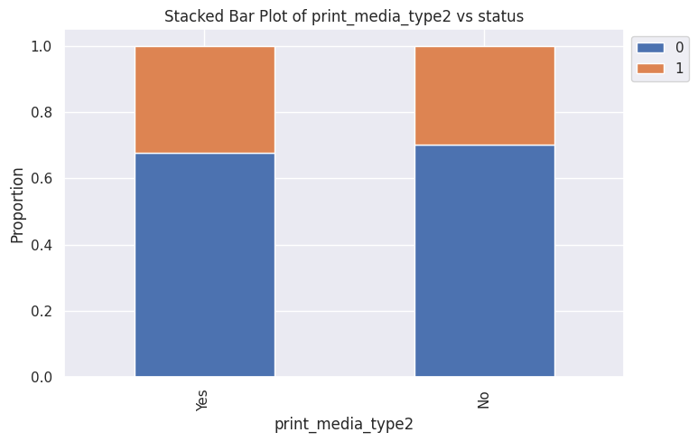

```python
predictor = "print_media_type2"
target = "status"

# Crosstab for raw counts
table_counts = pd.crosstab(datatest[predictor], datatest[target], margins=True)
print(table_counts)
print("-" * 120)

# Crosstab for normalized percentages
table_norm = pd.crosstab(datatest[predictor], datatest[target], normalize="index")

# Sorting by the least frequent target value
sorter = datatest[target].value_counts().index[-1]
table_norm = table_norm.sort_values(by=sorter, ascending=False)

# Plot stacked bar chart
table_norm.plot(kind="bar", stacked=True, figsize=(8, 5))

plt.legend(loc="upper left", bbox_to_anchor=(1, 1))
plt.xlabel(predictor)
plt.ylabel("Proportion")
plt.title(f"Stacked Bar Plot of {predictor} vs {target}")
plt.show()
```

```
status            0     1   All
digital_media
No             2876  1209  4085
Yes             359   168   527
All            3235  1377  4612
------------------------------------------------------------------------------------------------------------------------
```

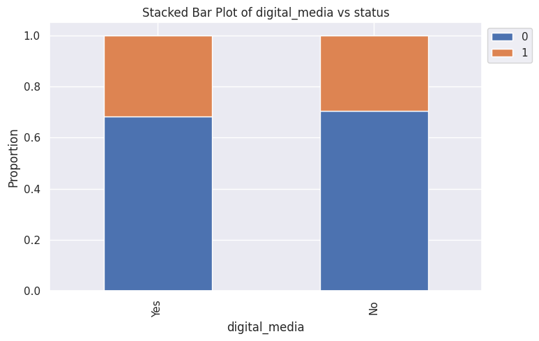

```python
predictor = "digital_media"
target = "status"

# Crosstab for raw counts
table_counts = pd.crosstab(datatest[predictor], datatest[target], margins=True)
print(table_counts)
print("-" * 120)

# Crosstab for normalized percentages
table_norm = pd.crosstab(datatest[predictor], datatest[target], normalize="index")

# Sorting by the least frequent target value
sorter = datatest[target].value_counts().index[-1]
table_norm = table_norm.sort_values(by=sorter, ascending=False)

# Plot stacked bar chart
table_norm.plot(kind="bar", stacked=True, figsize=(8, 5))

plt.legend(loc="upper left", bbox_to_anchor=(1, 1))
plt.xlabel(predictor)
plt.ylabel("Proportion")
plt.title(f"Stacked Bar Plot of {predictor} vs {target}")
plt.show()
```

```
status                   0     1   All
educational_channels
No                    2727  1180  3907
Yes                    508   197   705
All                   3235  1377  4612
------------------------------------------------------------------------------------------------------------------------
```

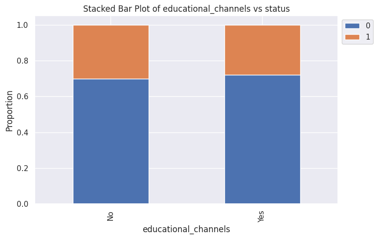

```python
predictor = "educational_channels"
target = "status"

# Crosstab for raw counts
table_counts = pd.crosstab(datatest[predictor], datatest[target], margins=True)
print(table_counts)
print("-" * 120)

# Crosstab for normalized percentages
table_norm = pd.crosstab(datatest[predictor], datatest[target], normalize="index")

# Sorting by the least frequent target value
sorter = datatest[target].value_counts().index[-1]
table_norm = table_norm.sort_values(by=sorter, ascending=False)

# Plot stacked bar chart
table_norm.plot(kind="bar", stacked=True, figsize=(8, 5))

plt.legend(loc="upper left", bbox_to_anchor=(1, 1))
plt.xlabel(predictor)
plt.ylabel("Proportion")
plt.title(f"Stacked Bar Plot of {predictor} vs {target}")
plt.show()
```

```
status       0     1   All
referral
No        3205  1314  4519
Yes         30    63    93
All       3235  1377  4612
------------------------------------------------------------------------------------------------------------------------
```

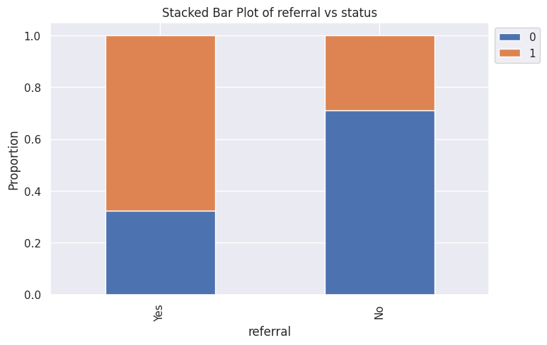

```python
predictor = "referral"
target = "status"

# Crosstab for raw counts
table_counts = pd.crosstab(datatest[predictor], datatest[target], margins=True)
print(table_counts)
print("-" * 120)

# Crosstab for normalized percentages
table_norm = pd.crosstab(datatest[predictor], datatest[target], normalize="index")

# Sorting by the least frequent target value
sorter = datatest[target].value_counts().index[-1]
table_norm = table_norm.sort_values(by=sorter, ascending=False)

# Plot stacked bar chart
table_norm.plot(kind="bar", stacked=True, figsize=(8, 5))

plt.legend(loc="upper left", bbox_to_anchor=(1, 1))
plt.xlabel(predictor)
plt.ylabel("Proportion")
plt.title(f"Stacked Bar Plot of {predictor} vs {target}")
plt.show()
```

The highest rate of conversion for the clients to convert seem to be referrals, as a trusted people close to the clients have their trust already. Because of this, it is important to make a referral program to bring in higher clients. Although, this information could be potentially clouded as very few people came in through referrals.

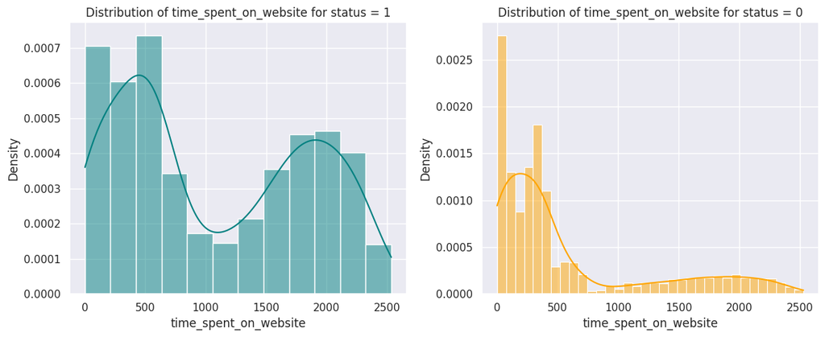

```python
predictor = "time_spent_on_website"
target = "status"

# Get unique values of target
target_uniq = datatest[target].unique()

plt.figure(figsize=(12, 5))

# Histogram for first target class
plt.subplot(1, 2, 1)
sns.histplot(datatest[datatest[target] == target_uniq[0]], x=predictor, kde=True, color="teal", stat="density")
plt.title(f"Distribution of {predictor} for {target} = {target_uniq[0]}")

# Histogram for second target class
plt.subplot(1, 2, 2)
sns.histplot(datatest[datatest[target] == target_uniq[1]], x=predictor, kde=True, color="orange", stat="density")
plt.title(f"Distribution of {predictor} for {target} = {target_uniq[1]}")

plt.tight_layout()
plt.show()
```

However, we can see the data outlers in the non-converted data. The information is right skewed, and the data is highly distrubuted because of the outliers on all the other rates.

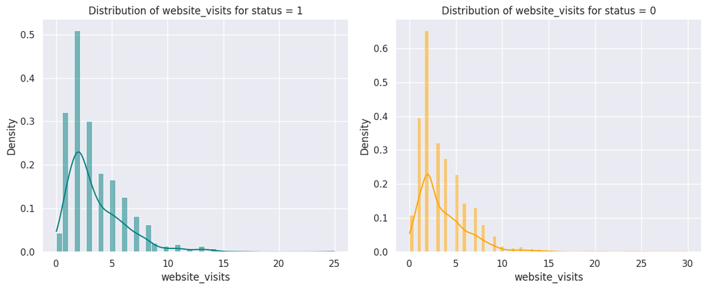

```python
predictor = "website_visits"
target = "status"

# Get unique values of target
target_uniq = datatest[target].unique()

plt.figure(figsize=(12, 5))

# Histogram for first target class
plt.subplot(1, 2, 1)
sns.histplot(datatest[datatest[target] == target_uniq[0]], x=predictor, kde=True, color="teal", stat="density")
plt.title(f"Distribution of {predictor} for {target} = {target_uniq[0]}")

# Histogram for second target class
plt.subplot(1, 2, 2)
sns.histplot(datatest[datatest[target] == target_uniq[1]], x=predictor, kde=True, color="orange", stat="density")
plt.title(f"Distribution of {predictor} for {target} = {target_uniq[1]}")

plt.tight_layout()
plt.show()
```

Both graphs demostrate rightly skewed data, however, we saw that although website visits may be few, the more time spent on it means there is a probability they will convert. From this, even though they might have a few visits, it might be a lengthy visit to convert.

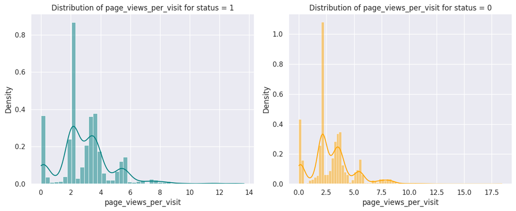

```python
predictor = "page_views_per_visit"
target = "status"

# Get unique values of target
target_uniq = datatest[target].unique()

plt.figure(figsize=(12, 5))

# Histogram for first target class
plt.subplot(1, 2, 1)
sns.histplot(datatest[datatest[target] == target_uniq[0]], x=predictor, kde=True, color="teal", stat="density")
plt.title(f"Distribution of {predictor} for {target} = {target_uniq[0]}")

# Histogram for second target class
plt.subplot(1, 2, 2)
sns.histplot(datatest[datatest[target] == target_uniq[1]], x=predictor, kde=True, color="orange", stat="density")
plt.title(f"Distribution of {predictor} for {target} = {target_uniq[1]}")

plt.tight_layout()
plt.show()
```

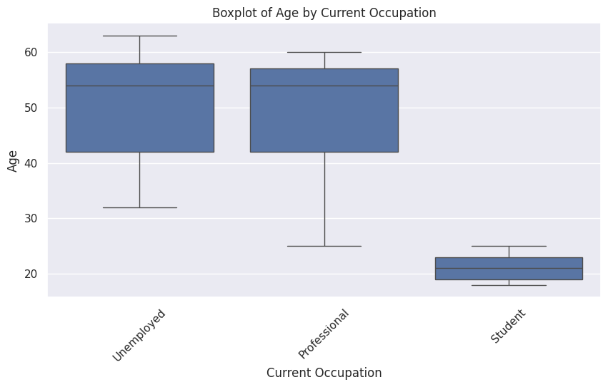

| current_occupation | count | mean | std | min | 25% | 50% | 75% | max |
| --- | --- | --- | --- | --- | --- | --- | --- | --- |
| Professional | 2616.0 | 49.347477 | 9.890744 | 25.0 | 42.0 | 54.0 | 57.0 | 60.0 |
| Student | 555.0 | 21.144144 | 2.001114 | 18.0 | 19.0 | 21.0 | 23.0 | 25.0 |
| Unemployed | 1441.0 | 50.140180 | 9.999503 | 32.0 | 42.0 | 54.0 | 58.0 | 63.0 |

```python
plt.figure(figsize=(10, 5))
sns.boxplot(data=datatest, x="current_occupation", y="age")
plt.xlabel("Current Occupation")
plt.ylabel("Age")
plt.title("Boxplot of Age by Current Occupation")
plt.xticks(rotation=45)
plt.show()

data.groupby(["current_occupation"])["age"].describe()
```

The information seems intuitive, students are approx/below 25 years old, and the professionals/unemployed people ranges. However, the median between the unemployed and professionals are about the same ranges.

## Data Preprocessing

- Missing value treatment (if needed)
- Feature engineering (if needed)
- Outlier detection and treatment (if needed)
- Preparing data for modeling
- Any other preprocessing steps (if needed)

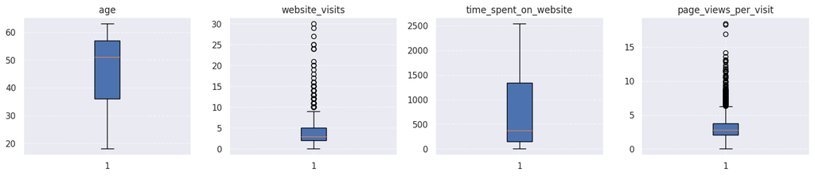

```python
# Select only numeric columns
numeric_columns = datatest.select_dtypes(include=np.number).columns.tolist()

# Drop "status" since it's categorical
if "status" in numeric_columns:
    numeric_columns.remove("status")

# Set figure size
plt.figure(figsize=(15, 12))

# Loop through each numeric column and plot a boxplot
for i in range(len(numeric_columns)):
    plt.subplot(4, 4, i + 1)  # Adjust grid size as needed
    plt.boxplot(datatest[numeric_columns[i]], vert=True, patch_artist=True, whis=1.5)
    plt.title(numeric_columns[i])
    plt.grid(True, linestyle="--", alpha=0.6)

# Adjust layout and show plots
plt.tight_layout()
plt.show()
```

High amount of outliers in the data can be found in website_visits and page_views_per_visit. Because we are using decision trees and random forests, they can deal with outliers just fine. It is not the best choice to get rid of these outliers as they could be important.

## EDA

- It is a good idea to explore the data once again after manipulating it.

I didn't manipulate it, I didnt do anything to the outliers.

```python
X = datatest.drop(["status"], axis=1) #all values but status because we want to predict status.
Y = datatest["status"] #only status is here because it is the data we want to predict and the dependable variable
X = pd.get_dummies(X, drop_first=True) #dummies of the data

from sklearn.model_selection import StratifiedShuffleSplit #function to mix the data

splitter = StratifiedShuffleSplit(n_splits=1, test_size=0.3, random_state=1)
for train_idx, test_idx in splitter.split(X, Y):
    X_train, X_test = X.iloc[train_idx], X.iloc[test_idx]
    y_train, y_test = Y.iloc[train_idx], Y.iloc[test_idx]
```

```python
train_shape = X_train.shape
test_shape = X_test.shape
train_dist = y_train.value_counts(normalize=True)
test_dist = y_test.value_counts(normalize=True)

summary = f"""
Dataset Split Summary:
----------------------
Training set: {train_shape}
Test set: {test_shape}

Class distribution in training set:
{train_dist}

Class distribution in test set:
{test_dist}
"""

print(summary)
```

```
Dataset Split Summary:
----------------------
Training set: (3228, 16)
Test set: (1384, 16)

Class distribution in training set:
status
0    0.701363
1    0.298637
Name: proportion, dtype: float64

Class distribution in test set:
status
0    0.70159
1    0.29841
Name: proportion, dtype: float64
```

```python
#function to do the confusion metrics without having to repeat the code over and over again
def metrics_score(y_true, y_pred):
    # Print classification report
    report = classification_report(y_true, y_pred)
    print("Model Performance Report:\n", report)

    # Generate confusion matrix
    conf_matrix = confusion_matrix(y_true, y_pred)

    # Plot confusion matrix
    plt.figure(figsize=(8, 5))
    sns.heatmap(conf_matrix, annot=True, cmap="Blues", fmt=".0f",
                xticklabels=["Not Converted", "Converted"],
                yticklabels=["Not Converted", "Converted"])

    plt.xlabel("Predicted Labels")
    plt.ylabel("Actual Labels")
    plt.title("Confusion Matrix")
    plt.show()
```

## Building a Decision Tree model

```python
model_dt= DecisionTreeClassifier(random_state=1,max_depth=8)
model_dt.fit(X_train, y_train)
```

```
DecisionTreeClassifier(max_depth=8, random_state=1)
```

```python
y_pred_train = model_dt.predict(X_train)
```

```
Model Performance Report:
               precision    recall  f1-score   support

           0       0.94      0.91      0.92      2264
           1       0.80      0.87      0.83       964

    accuracy                           0.90      3228
   macro avg       0.87      0.89      0.88      3228
weighted avg       0.90      0.90      0.90      3228
```

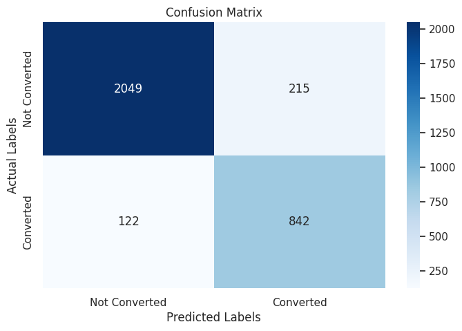

```python
metrics_score(y_train, y_pred_train)
```

On the training data, this is doing pretty well. The recall rate is of 0.87%, which is our priority because we want to avoid false negatives at all costs. It is better to lose a few resources on a false positive than not provide a good service to a false negative and lose a potential client.

The recall rate is 0.87 which is capturing majority of actual conversions, the f1 score is decent with 0.83 which means theres a good trade-off between precision and recall. The accuracy overall is of 90%, which is not a reliable rate by itself, but the model still provides good results.

```
Model Performance Report:
               precision    recall  f1-score   support

           0       0.91      0.87      0.89       971
           1       0.72      0.79      0.75       413

    accuracy                           0.85      1384
   macro avg       0.81      0.83      0.82      1384
weighted avg       0.85      0.85      0.85      1384
```

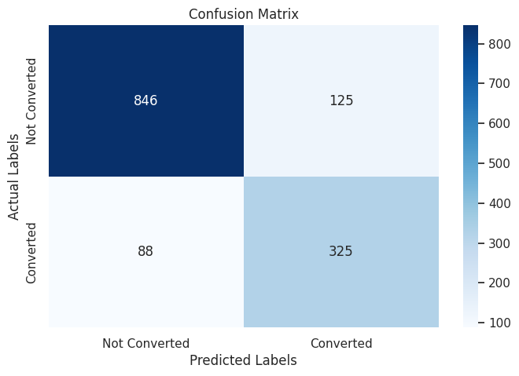

```python
y_pred_test1 = model_dt.predict(X_test)

# Evaluate performance on the test data
metrics_score(y_test, y_pred_test1)
```

The previous data was of the training data, this is now the test data. We can see the model was slightly overfitting, as some metrics changed. The recall class is still strong at 0.79%, but this can be improved. The precision rate of class 1 dropped, of 0,72, which means some predicted conversions are false positives.

## Do we need to prune the tree?

```
Model Performance Report:
               precision    recall  f1-score   support

           0       0.95      0.75      0.84      2264
           1       0.60      0.91      0.72       964

    accuracy                           0.79      3228
   macro avg       0.78      0.83      0.78      3228
weighted avg       0.85      0.79      0.80      3228
```

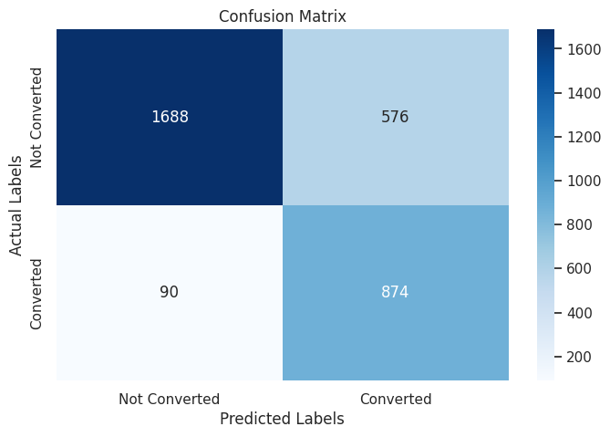

```
Model Performance Report:
               precision    recall  f1-score   support

           0       0.94      0.73      0.82       971
           1       0.58      0.89      0.70       413

    accuracy                           0.78      1384
   macro avg       0.76      0.81      0.76      1384
weighted avg       0.83      0.78      0.79      1384
```

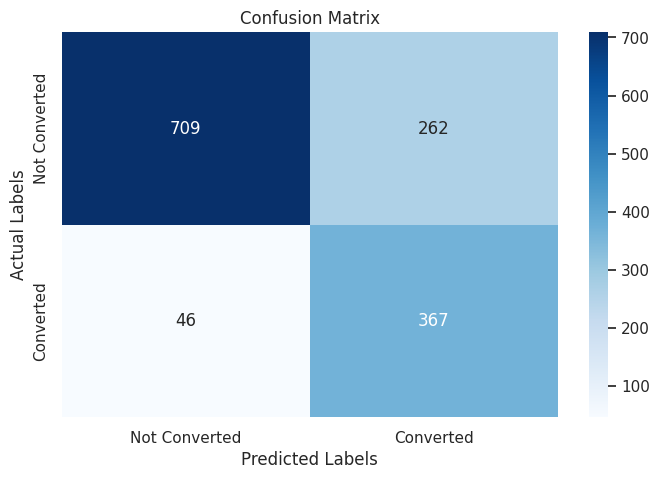

```python
# Importing the necessary functions
from sklearn import metrics
from sklearn.metrics import recall_score

# Initializing the Decision Tree Classifier with class weights
model_dt_tuned = DecisionTreeClassifier(random_state=7, class_weight={0: 0.3, 1: 0.7})

# Defining the parameter grid for tuning
param_grid = {
    'max_depth': np.arange(2, 10),
    'criterion': ['gini', 'entropy'],
    'min_samples_leaf': [5, 10, 20, 25]
}

# Setting up the scorer with recall for class 1 (positive class)
scorer = metrics.make_scorer(recall_score, pos_label=1)

# Performing grid search with cross-validation (5-fold)
grid_search = GridSearchCV(model_dt_tuned, param_grid, scoring=scorer, cv=5)

# Fitting the grid search to the training data
grid_search.fit(X_train, y_train)

# Updating the model with the best parameters found
model_dt_tuned = grid_search.best_estimator_

# Fitting the tuned model on the training data
model_dt_tuned.fit(X_train, y_train)

# Model performance on training data
y_pred_train_tuned = model_dt_tuned.predict(X_train)
metrics_score(y_train, y_pred_train_tuned)

# Model performance on testing data
y_pred_test_tuned = model_dt_tuned.predict(X_test)
metrics_score(y_test, y_pred_test_tuned)
```

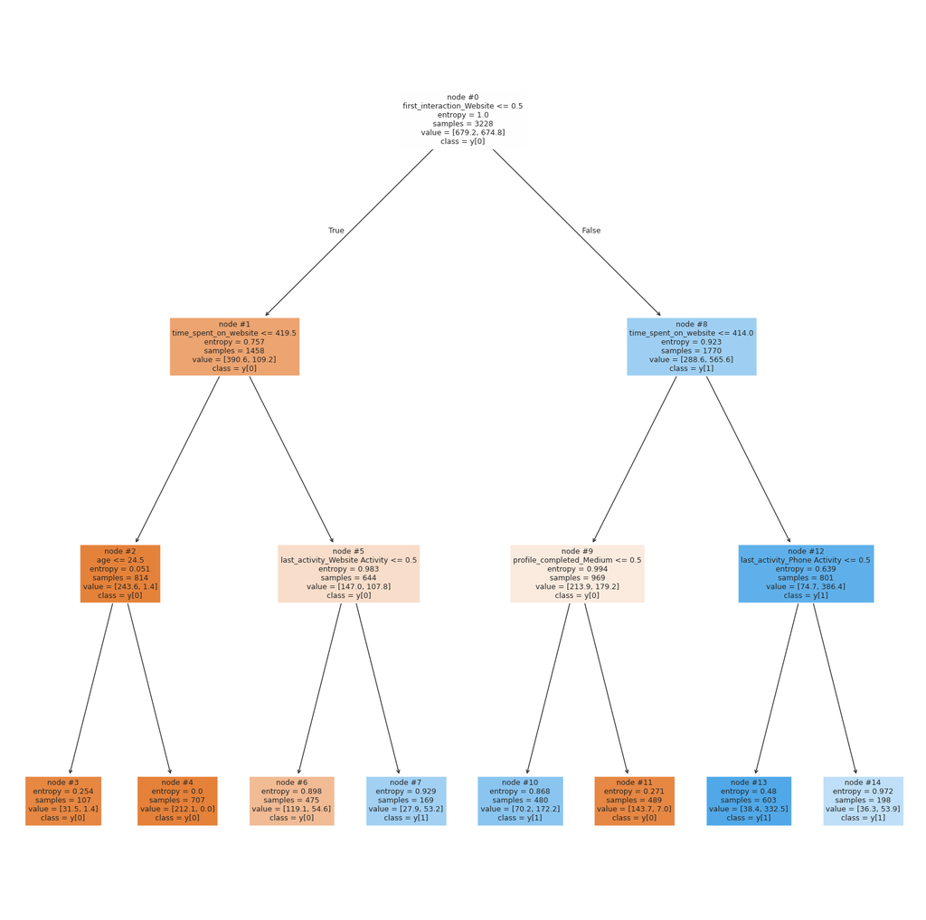

```python
from sklearn.tree import plot_tree


features = list(X.columns)

plt.figure(figsize = (20, 20))

plot_tree(model_dt_tuned, feature_names=features, filled=True, fontsize=9, node_ids=True, class_names=True)

plt.show()
```

```
                                     Imp
time_spent_on_website           0.365546
first_interaction_Website       0.313484
profile_completed_Medium        0.233702
last_activity_Phone Activity    0.048402
last_activity_Website Activity  0.032013
age                             0.006853
website_visits                  0.000000
page_views_per_visit            0.000000
current_occupation_Student      0.000000
current_occupation_Unemployed   0.000000
profile_completed_Low           0.000000
print_media_type1_Yes           0.000000
print_media_type2_Yes           0.000000
digital_media_Yes               0.000000
educational_channels_Yes        0.000000
referral_Yes                    0.000000
```

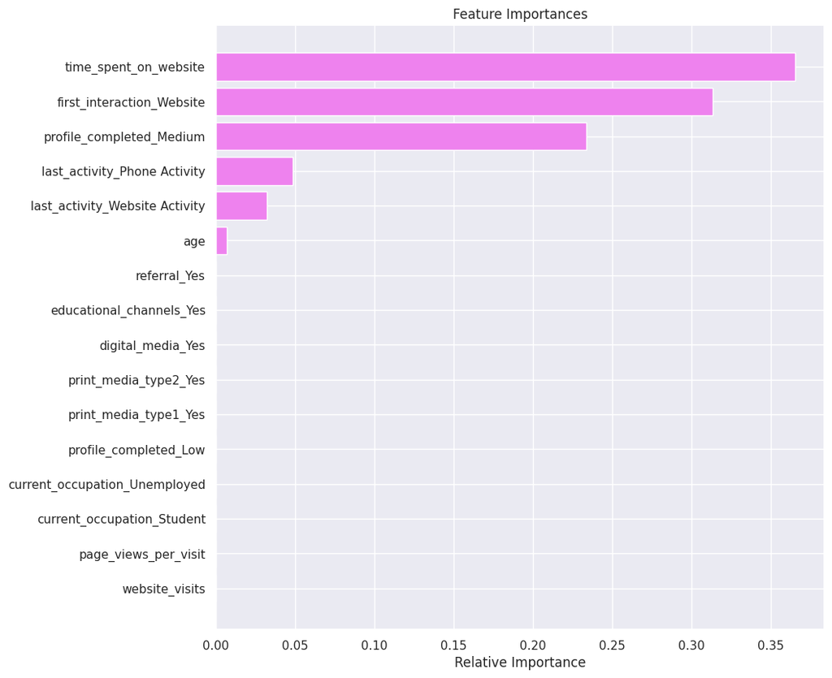

```python
# Importance of features in the tree building
print(pd.DataFrame(model_dt_tuned.feature_importances_, columns=["Imp"], index=X_train.columns).sort_values(by='Imp', ascending=False))

# Plotting the feature importance
importances = model_dt_tuned.feature_importances_

indices = np.argsort(importances)

plt.figure(figsize=(10, 10))

plt.title('Feature Importances')

plt.barh(range(len(indices)), importances[indices], color='violet', align='center')

plt.yticks(range(len(indices)), [features[i] for i in indices])

plt.xlabel('Relative Importance')

plt.show()
```

The feature importances picked by the decision model are the following: Time spent on website, first interaction on website, profile completed, website/phone activity and age.

## Building a Random Forest model

```python
# Fitting the Random Forest classifier on the training data
rf_estimator = RandomForestClassifier(random_state = 1)

rf_estimator.fit(X_train, y_train)
```

```
RandomForestClassifier(random_state=1)
```

```
Model Performance Report:
               precision    recall  f1-score   support

           0       1.00      1.00      1.00      2264
           1       1.00      1.00      1.00       964

    accuracy                           1.00      3228
   macro avg       1.00      1.00      1.00      3228
weighted avg       1.00      1.00      1.00      3228
```

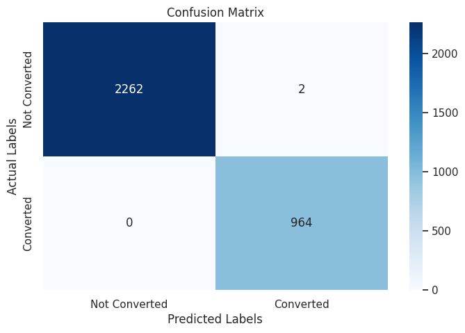

```python
y_pred_train_rf = rf_estimator.predict(X_train)

metrics_score(y_train, y_pred_train_rf)
```

This is "too good to be true" kind of situation. It is clearly overfitting on the training data.

```
Model Performance Report:
               precision    recall  f1-score   support

           0       0.89      0.91      0.90       971
           1       0.78      0.73      0.76       413

    accuracy                           0.86      1384
   macro avg       0.83      0.82      0.83      1384
weighted avg       0.86      0.86      0.86      1384
```

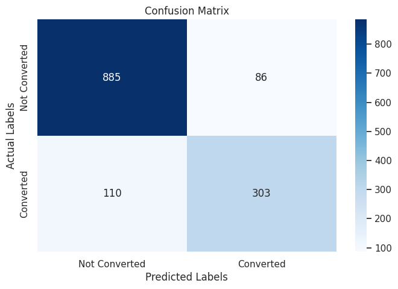

```python
# Checking performance on the testing data
y_pred_test_rf = rf_estimator.predict(X_test)

metrics_score(y_test, y_pred_test_rf)
```

Our priority is recall and it has a score of 0.73, which is not a good score at all because recall is our priority. This model clearly needs to be tuned and improved.

## Do we need to prune the tree?

```
Model Performance Report:
               precision    recall  f1-score   support

           0       0.94      0.82      0.88      2264
           1       0.68      0.88      0.77       964

    accuracy                           0.84      3228
   macro avg       0.81      0.85      0.82      3228
weighted avg       0.86      0.84      0.84      3228
```

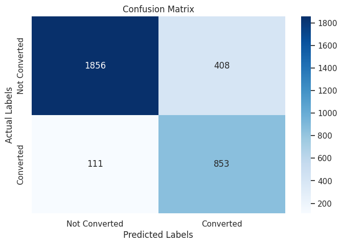

```python
# Initialize the Random Forest estimator with entropy criterion
rf_estimator_tuned = RandomForestClassifier(criterion="entropy", random_state=7)

# Define the parameter grid for hyperparameter tuning
param_grid = {
    "n_estimators": [110, 120],
    "max_depth": [6, 7],
    "min_samples_leaf": [20, 25],
    "max_features": [0.8, 0.9],
    "max_samples": [0.9, 1],
    "class_weight": ["balanced", {0: 0.3, 1: 0.7}]
}

# Set up the recall scorer for class 1 (positive class)
scorer = metrics.make_scorer(recall_score, pos_label=1)

# Perform grid search with cross-validation (cv=5) on the training data
grid_search = GridSearchCV(rf_estimator_tuned, param_grid, scoring=scorer, cv=5)

# Fit the grid search to the training data
grid_search.fit(X_train, y_train)

# Update the estimator with the best parameters found from the grid search
rf_estimator_tuned = grid_search.best_estimator_

# Fit the best estimator on the training data
rf_estimator_tuned.fit(X_train, y_train)

# Model performance on the training data
y_pred_train_rf = rf_estimator_tuned.predict(X_train)
metrics_score(y_train, y_pred_train_rf)
```

```
Model Performance Report:
               precision    recall  f1-score   support

           0       0.93      0.81      0.86       971
           1       0.65      0.85      0.74       413

    accuracy                           0.82      1384
   macro avg       0.79      0.83      0.80      1384
weighted avg       0.85      0.82      0.83      1384
```

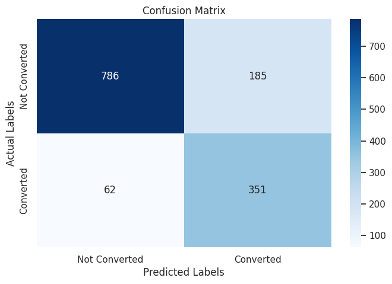

```python
y_pred_test_rf_tuned = rf_estimator_tuned.predict(X_test)
metrics_score(y_test, y_pred_test_rf_tuned)
```

Clear improvement from the previous model that wasn't tuned. The reall rate is of 0.85% which is good because it's our priority, however, the rate of false positives in pretty high. It is still a decent model. In comparasion to the tuned decision tree, this model is the best one because it a better prediction rate, RF has fewer false positives which can save on resources, although DT has a higher recall, it still predicts values pretty well. Overall, RF has a better balance.

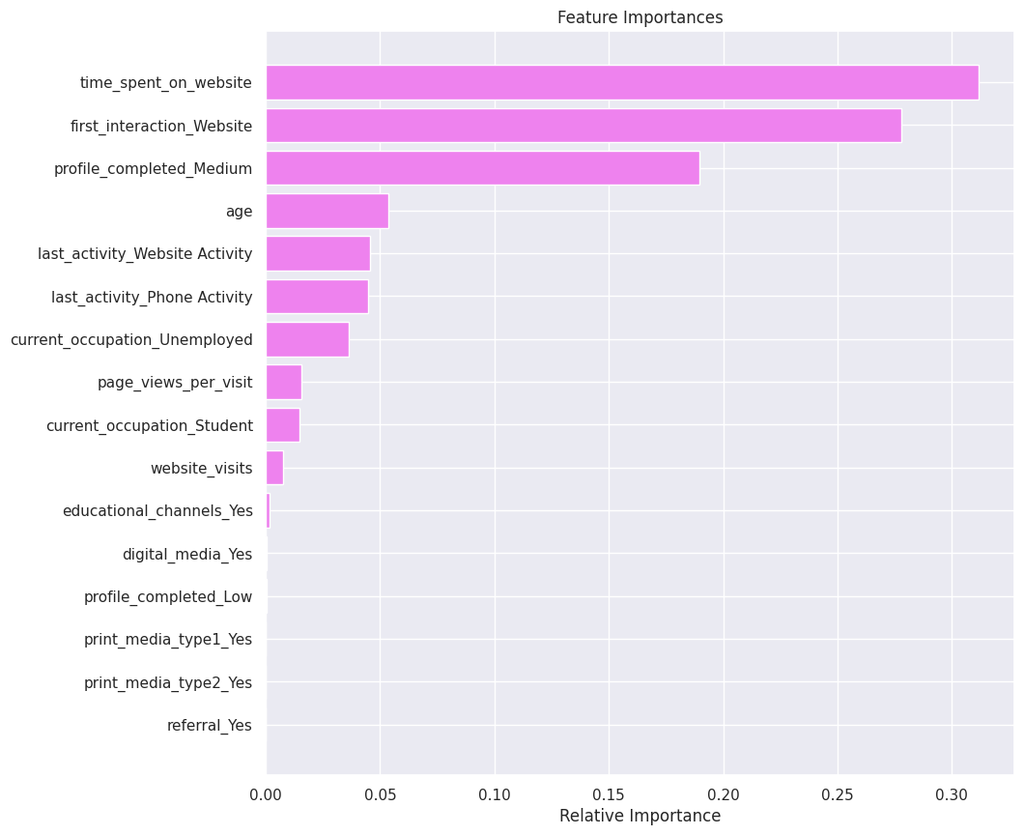

```python
# Get the feature importances from the trained model
importances = rf_estimator_tuned.feature_importances_

# Get the indices of the features sorted by importance
indices = np.argsort(importances)

# Plot the feature importances
plt.figure(figsize=(10, 10))
plt.title('Feature Importances')
plt.barh(range(len(indices)), importances[indices], color='violet', align='center')
plt.yticks(range(len(indices)), [X_train.columns[i] for i in indices])
plt.xlabel('Relative Importance')
plt.show()
```

Like the previous model, the feature importance are similar but this model has more feature importances. It includes educational channels, ocupation, etc. Because it saw more feature importances, it makes good predictions.

## Actionable Insights and Recommendations

- Make improvements on the websites so users are hooked on to using it more and staying longer, which could potentially make the conversion of rate higher (this had a higher importance)
- Although the referral rate could be unreliable as only 2.3% of users were through referrals, it could be a good choice to make referral programs so that more people come in through referrals because of the higher conversion rate.
- Magazines are not the best choice of bringing in new clients, so it might be best to put those resources into other medias. Referrals, education channels, etc.
- Educational channels was the second highest of conversion rate, so make a priority to make new programs with educational channels to bring in more clients with higher chance of converting.